# **Transmisión dinámica de la política monetaria y factores macroeconómicos sobre la inflación en Colombia: un enfoque VAR (quarto)**

##### 4.6.8.1 Funciones impulso–respuesta (IRFs)

Las funciones impulso–respuesta se estimaron para cuantificar el efecto dinámico de choques en el bloque endógeno del VARX(2) sobre la inflación anual de Colombia. Dado el rechazo de normalidad y la evidencia de heterocedasticidad condicional en los residuos, se reportan intervalos de confianza bootstrap al 95% (2000 réplicas), lo cual permite una inferencia más robusta ante innovaciones no gaussianas.

**Choque en la DTF → Inflación Colombia.** La respuesta de la inflación ante un choque positivo en la tasa DTF es inicialmente **positiva**, alcanzando su máximo alrededor de los **5–7 meses**, y posteriormente se revierte gradualmente hacia valores cercanos a cero e incluso levemente negativos en horizontes largos. Este perfil sugiere una transmisión monetaria con **rezago** y con una dinámica no monotónica. La amplitud de los intervalos bootstrap indica que la significancia estadística es mayor en el corto plazo y se debilita en horizontes largos.

**Choque en la TRM → Inflación Colombia.** La inflación responde **positivamente** a un choque en la TRM (variación interanual del tipo de cambio), con un incremento que se acumula y alcanza un máximo aproximadamente entre **8 y 12 meses**, para luego disiparse lentamente. Este patrón es consistente con un mecanismo de **pass-through cambiario**: una depreciación (o mayor crecimiento anual del tipo de cambio) se transmite a precios internos con rezagos, y su efecto se mantiene durante varios trimestres antes de extinguirse.

**Choque en el ISE → Inflación Colombia.** Un choque positivo en el ISE (proxy de actividad) genera una respuesta **positiva** de la inflación, con un pico alrededor de los **8–11 meses**, seguido de una convergencia gradual hacia cero. Económicamente, este resultado es coherente con un canal de demanda: aumentos en la actividad agregada presionan al alza los precios con rezagos, especialmente cuando existen rigideces nominales.

En conjunto, las IRFs sugieren que (i) los choques cambiarios y reales presentan efectos inflacionarios persistentes en horizontes cercanos a un año, y (ii) los choques monetarios muestran un efecto transitorio que tiende a disiparse y revertirse en el largo plazo. En todos los casos, el uso de bandas bootstrap permite interpretar los resultados con cautela, especialmente en horizontes amplios donde la incertidumbre aumenta.

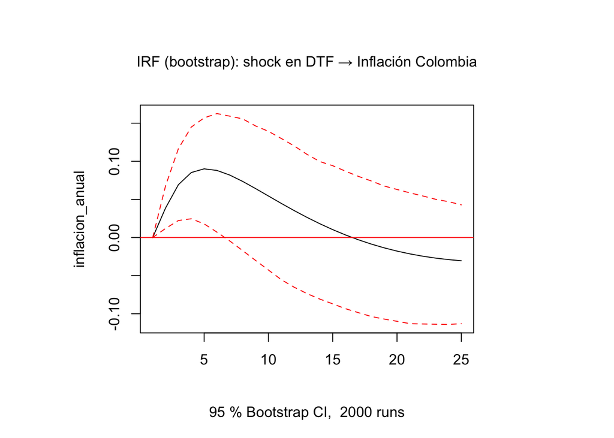

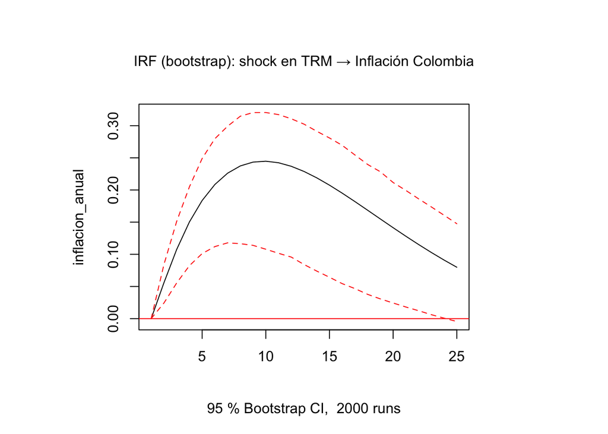

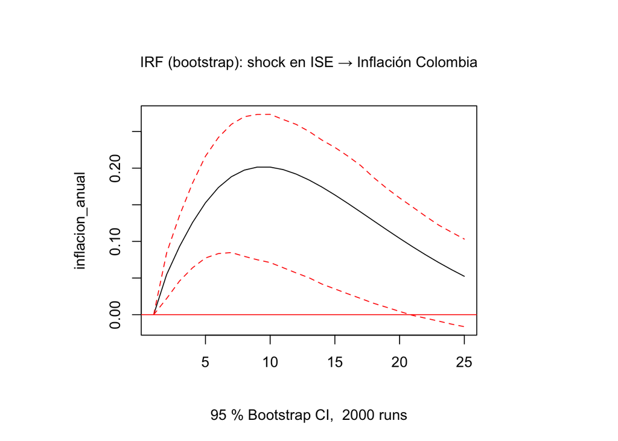

##### 4.6.8.2 Descomposición de varianza del error de pronóstico (FEVD)

```
      inflacion_anual    TRM_log ise_dae_log   DTF_nivel
 [1,]       1.0000000 0.00000000  0.00000000 0.000000000
 [2,]       0.9511180 0.01999073  0.01926552 0.009625796
 [3,]       0.8835354 0.05232062  0.04165370 0.022490308
 [4,]       0.8122674 0.08929722  0.06589430 0.032541132
 [5,]       0.7437260 0.12676872  0.09075765 0.038747603
 [6,]       0.6809601 0.16242294  0.11484490 0.041772038
 [7,]       0.6252211 0.19509631  0.13710142 0.042581145
 [8,]       0.5767218 0.22433220  0.15694595 0.042000087
 [9,]       0.5350988 0.25008535  0.17418730 0.040628547
[10,]       0.4997101 0.27253109  0.18888826 0.038870506
[11,]       0.4698166 0.29194818  0.20124908 0.036986099
[12,]       0.4446841 0.30865072  0.21152807 0.035137069
[13,]       0.4236341 0.32295104  0.21999473 0.033420173
[14,]       0.4060633 0.33514137  0.22690536 0.031889943
[15,]       0.3914477 0.34548637  0.23249234 0.030573621
[16,]       0.3793366 0.35422160  0.23696103 0.029480781
[17,]       0.3693450 0.36155504  0.24049042 0.028609503
[18,]       0.3611443 0.36766984  0.24323549 0.027950341
[19,]       0.3544537 0.37272743  0.24532997 0.027488927
[20,]       0.3490326 0.37687053  0.24688912 0.027207724
[21,]       0.3446750 0.38022571  0.24801207 0.027087261
[22,]       0.3412034 0.38290553  0.24878398 0.027107048
[23,]       0.3384657 0.38501029  0.24927771 0.027246292
[24,]       0.3363309 0.38662935  0.24955525 0.027484476
```

La FEVD de la inflación anual permite cuantificar qué proporción de la incertidumbre del pronóstico de la inflación se explica por choques propios versus choques provenientes de las demás variables endógenas del sistema.

En el **muy corto plazo**, la variación del error de pronóstico de la inflación está dominada por choques propios: a un paso adelante, el **100%** se explica por innovaciones de la inflación. Sin embargo, a medida que aumenta el horizonte, la importancia relativa de los choques propios disminuye de forma sostenida.

Hacia el horizonte de **24 meses**, la FEVD indica que aproximadamente: - **33.6%** de la varianza del error de pronóstico de la inflación se explica por **choques propios** de inflación, - **38.7%** se explica por choques en la **TRM**, - **25.0%** se explica por choques en el **ISE**, - y alrededor de **2.7%** por choques en la **DTF**.

Este patrón sugiere que, en horizontes medios y largos, la dinámica inflacionaria en Colombia está fuertemente influenciada por choques **cambiarios** y por el componente **real** (actividad económica), mientras que los choques monetarios medidos por la DTF aportan una fracción relativamente menor a la varianza del error de pronóstico. En términos económicos, el resultado es consistente con un contexto donde el canal cambiario y los choques reales contribuyen de manera importante a la incertidumbre inflacionaria, especialmente en una economía abierta.

Finalmente, estos resultados complementan las IRFs: mientras las IRFs muestran el perfil temporal del efecto de un choque, la FEVD resume la importancia relativa de cada fuente de innovación en la explicación del comportamiento dinámico de la inflación a distintos horizontes.

## 5. Predicción y capacidad predictiva del modelo VARX

### 5.1 Diseño del ejercicio fuera de muestra (out-of-sample)

El desempeño predictivo del modelo VARX se evalúa mediante un ejercicio fuera de muestra, separando la información disponible en un periodo de estimación (*train*) y un periodo de evaluación (*test*). El modelo se estima únicamente con datos del periodo *train* y se generan pronósticos para el periodo *test*, el cual no interviene en la estimación.

Este enfoque permite evaluar la capacidad predictiva del modelo en un entorno análogo al pronóstico en tiempo real, reduciendo el riesgo de sobreajuste y proporcionando evidencia empírica sobre la utilidad del enfoque multivariado para anticipar la trayectoria de la inflación en Colombia.

### 5.2 Pronóstico fuera de muestra con VARX (Realized-X)

En un modelo VARX, los pronósticos del bloque endógeno dependen tanto de sus rezagos como de la trayectoria de las variables exógenas. Para evaluar el desempeño predictivo del modelo se adopta el enfoque **Realized-X**, donde durante el periodo de evaluación (*test*) se utilizan los valores observados de las variables exógenas (inflación de EE.UU. y precio del petróleo Brent). Este enfoque permite evaluar la capacidad del VARX para transformar condiciones externas observadas en predicciones de inflación doméstica, sin introducir error adicional por el pronóstico de las exógenas.

```
VARX RMSE:  2.104038
```

```
VARX RMSE:  1.930529
```

### 5.3 Modelos de referencia (benchmarks)

Para contextualizar el desempeño predictivo del VARX, se comparan sus errores de pronóstico fuera de muestra con modelos univariados estándar. En particular, se consideran:

1. **ARIMA univariado** para la inflación anual de Colombia, estimado únicamente con información del periodo *train*.
2. **Naive** (persistencia): el pronóstico para el siguiente periodo es igual al último valor observado en *train*.

Estos benchmarks permiten evaluar si el enfoque multivariado aporta mejoras predictivas más allá de reglas simples o modelos univariados flexibles.

```
ARIMA RMSE:  1.895487
```

```
ARIMA MAE:  1.413347
```

```
NAIVE RMSE:  5.434015
```

```
NAIVE RMSE:  4.700426
```

### 5.4 Resultados: comparación con modelos de referencia

El desempeño predictivo fuera de muestra del VARX(2) se evaluó mediante RMSE y MAE, y se comparó frente a dos benchmarks: un ARIMA univariado para la inflación anual y un modelo naive de persistencia.

Los resultados indican que el VARX(2) supera ampliamente al benchmark naive: el RMSE se reduce en aproximadamente **61.3%** y el MAE en **58.9%**, lo que sugiere que el modelo multivariado incorpora información relevante sobre la dinámica inflacionaria más allá de una regla de persistencia simple.

No obstante, al comparar con el ARIMA univariado, el VARX(2) presenta un desempeño inferior: el RMSE es aproximadamente **11.0%** mayor y el MAE alrededor de **36.6%** mayor. Esto sugiere que, para el periodo de evaluación considerado y bajo el esquema Realized-X, un modelo univariado flexible captura con mayor precisión estadística la trayectoria de la inflación.

En conjunto, la evidencia muestra que el VARX(2) aporta mejoras sustanciales frente a pronósticos ingenuos, pero no domina al benchmark ARIMA en términos de error promedio. En consecuencia, el valor agregado del VARX se interpreta principalmente en su capacidad para incorporar mecanismos económicos (canal cambiario, real y monetario) y para realizar análisis dinámico (IRFs/FEVD), mientras que el desempeño predictivo puede fortalecerse mediante estrategias adicionales (p. ej., ventanas crecientes, selección de horizonte, o escenarios para exógenas).

### 5.5 Validación fuera de muestra con ventana creciente (expanding window)

Con el fin de aproximar el proceso de pronóstico en tiempo real, se implementa un ejercicio de validación fuera de muestra con **ventana creciente** (*expanding window*). En cada fecha de origen dentro del periodo *test*, el modelo se re-estima utilizando toda la información disponible hasta ese momento y se generan pronósticos a horizontes $h \in {1,3,6,12}$ meses.

Este diseño permite evaluar no solo la precisión promedio del modelo, sino también su desempeño relativo a distintos horizontes de pronóstico, evitando que los resultados dependan de una única estimación fija. Para el modelo VARX, el pronóstico se realiza bajo el enfoque **Realized-X**, utilizando los valores observados de las variables exógenas (inflación de EE.UU. y Brent) dentro del periodo de evaluación.

Expanding window: desempeño predictivo por horizonte (inflación Colombia)

| h | RMSE_VARX | MAE_VARX | RMSE_ARIMA | MAE_ARIMA | RMSE_NAIVE | MAE_NAIVE | RMSE_gain_vs_naive | RMSE_gain_vs_arima | MAE_gain_vs_naive | MAE_gain_vs_arima |
| --- | --- | --- | --- | --- | --- | --- | --- | --- | --- | --- |
| 1 | 0.2321 | 0.1970 | 0.2419 | 0.1758 | 0.4128 | 0.3443 | 43.7780 | 4.0463 | 42.7664 | -12.0941 |
| 3 | 0.5766 | 0.4863 | 0.7919 | 0.6252 | 1.1415 | 1.0095 | 49.4842 | 27.1834 | 51.8255 | 22.2116 |
| 6 | 0.7033 | 0.6061 | 1.5991 | 1.3129 | 2.0895 | 1.9203 | 66.3433 | 56.0213 | 68.4387 | 53.8359 |
| 12 | 1.2102 | 0.8316 | 2.7840 | 2.3306 | 3.7165 | 3.3423 | 67.4362 | 56.5294 | 75.1184 | 64.3176 |

### Interpretación de la validación expanding window

La validación fuera de muestra con ventana creciente muestra que el desempeño predictivo del VARX(2) depende del horizonte de pronóstico. A un mes (h = 1), el VARX presenta un RMSE ligeramente inferior al ARIMA, aunque el ARIMA obtiene un menor MAE, lo cual es consistente con la alta persistencia de la inflación y con la fortaleza de modelos univariados para pronósticos de muy corto plazo.

Sin embargo, a horizontes medios y largos el VARX domina de forma sistemática. En particular, para h = 3, 6 y 12 meses, el VARX reduce de manera sustancial tanto el RMSE como el MAE frente al ARIMA (ganancias superiores al 20% a tres meses y superiores al 50% a seis y doce meses). Este patrón sugiere que la información contenida en el bloque macroeconómico doméstico (TRM, ISE, DTF) y en los determinantes externos (inflación de EE.UU. y Brent, bajo Realized-X) aporta capacidad predictiva adicional cuando el horizonte de pronóstico se amplía.

En comparación con el benchmark naive, el VARX exhibe mejoras pronunciadas en todos los horizontes, lo que confirma que el enfoque multivariado captura dinámica relevante más allá de una regla de persistencia simple. En conjunto, la evidencia respalda el uso del VARX(2) como herramienta de pronóstico, particularmente para horizontes de política y análisis macroeconómico donde el interés se concentra en proyecciones trimestrales y anuales.

Expanding window: desempeño predictivo del VARX(2) vs ARIMA por horizonte (inflación Colombia)

| Horizonte | RMSE VARX | RMSE ARIMA | Δ RMSE vs ARIMA (%) | MAE VARX | MAE ARIMA | Δ MAE vs ARIMA (%) |
| --- | --- | --- | --- | --- | --- | --- |
| 1 | 0.232 | 0.242 | 4.046 | 0.197 | 0.176 | -12.094 |
| 3 | 0.577 | 0.792 | 27.183 | 0.486 | 0.625 | 22.212 |
| 6 | 0.703 | 1.599 | 56.021 | 0.606 | 1.313 | 53.836 |
| 12 | 1.210 | 2.784 | 56.529 | 0.832 | 2.331 | 64.318 |

**Nota:** La ganancia relativa frente a ARIMA se define como

$100\times(\text{Error}_{ARIMA}-\text{Error}_{VARX})/\text{Error}_{ARIMA}\\$

Valores positivos indican que el VARX reduce el error respecto a ARIMA.

### 5.6 Pronóstico hacia adelante de la inflación (2025-12 a 2026-07)

Una vez validado el desempeño fuera de muestra mediante ventana creciente, se construye un pronóstico hacia adelante desde el último dato disponible de la muestra (2025-11). Dado que el modelo es un VARX, el pronóstico del bloque endógeno depende de la trayectoria futura de las variables exógenas (inflación de EE.UU. y Brent). En ausencia de valores observados para el periodo 2025-12 a 2026-07, se adopta el enfoque **Forecast-X**, proyectando las exógenas con modelos ARIMA univariados e incorporándolas como trayectoria condicionante del VARX.

En consecuencia, las proyecciones deben interpretarse como **pronósticos condicionales** al escenario implícito generado por el Forecast-X.

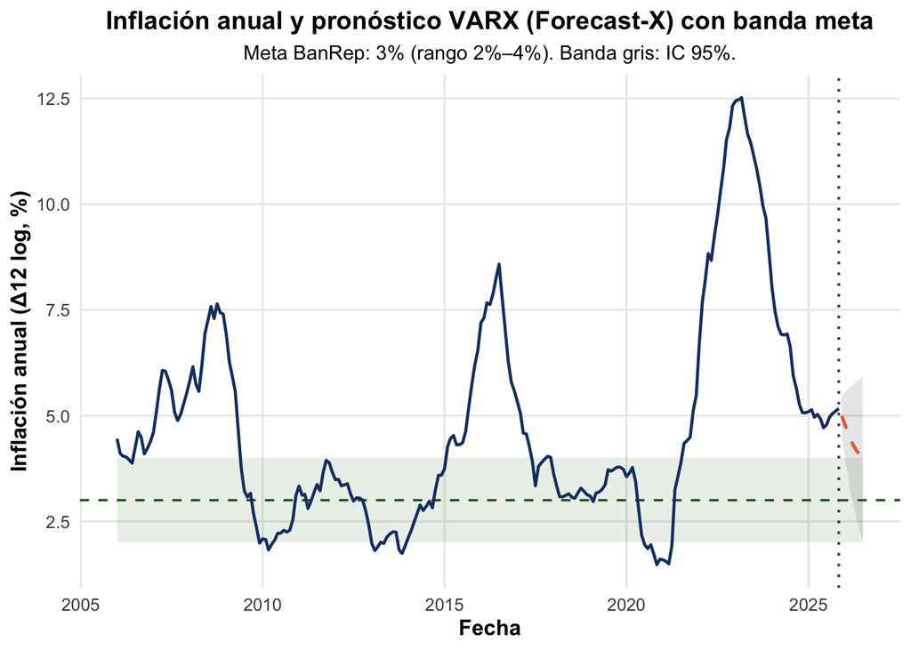

### 5.7 Interpretación del pronóstico respecto a la meta de inflación

La figura anterior compara la trayectoria histórica de la inflación anual (definida como $\Delta_{12}\log(IPC)\times 100)$ con el pronóstico del VARX bajo el enfoque Forecast-X para las variables exógenas. Se incluye la banda de meta de inflación del Banco de la República (3% con rango de tolerancia 2%–4%) como referencia de política monetaria.

En términos de política monetaria, el pronóstico central se aproxima progresivamente al rango meta, aunque la convergencia depende de la trayectoria futura de los determinantes externos (inflación de EE.UU. y precios del petróleo) y de la respuesta endógena del sistema (TRM, actividad económica y condiciones monetarias). Por ello, este ejercicio debe interpretarse como un pronóstico condicional a la información disponible y al escenario implícito en la proyección de las variables exógenas.

Pronóstico condicional de inflación anual (VARX, Forecast-X), 2025-12 a 2026-07

| fecha | inflacion_pred | inflacion_lo | inflacion_hi |
| --- | --- | --- | --- |
| 2025-12-01 | 4.997 | 4.539 | 5.456 |
| 2026-01-01 | 4.787 | 4.014 | 5.560 |
| 2026-02-01 | 4.590 | 3.553 | 5.628 |
| 2026-03-01 | 4.421 | 3.155 | 5.686 |
| 2026-04-01 | 4.278 | 2.812 | 5.745 |
| 2026-05-01 | 4.162 | 2.517 | 5.807 |
| 2026-06-01 | 4.069 | 2.263 | 5.874 |
| 2026-07-01 | 3.997 | 2.047 | 5.946 |

```r
# Causalidad de Granger desde DTF hacia inflación
vars::causality(varx_full, cause = "DTF_nivel")
```

```
$Granger

    Granger causality H0: DTF_nivel do not Granger-cause inflacion_anual
    TRM_log ise_dae_log

data:  VAR object varx_full
F-Test = 2.1743, df1 = 6, df2 = 900, p-value = 0.04334


$Instant

    H0: No instantaneous causality between: DTF_nivel and inflacion_anual
    TRM_log ise_dae_log

data:  VAR object varx_full
Chi-squared = 6.3691, df = 3, p-value = 0.09497
```

```r
# TRM -> inflación
vars::causality(varx_full, cause = "TRM_log")
```

```
$Granger

    Granger causality H0: TRM_log do not Granger-cause inflacion_anual
    ise_dae_log DTF_nivel

data:  VAR object varx_full
F-Test = 6.3137, df1 = 6, df2 = 900, p-value = 1.618e-06


$Instant

    H0: No instantaneous causality between: TRM_log and inflacion_anual
    ise_dae_log DTF_nivel

data:  VAR object varx_full
Chi-squared = 0.68615, df = 3, p-value = 0.8765
```

```r
# ISE -> inflación
vars::causality(varx_full, cause = "ise_dae_log")
```

```
$Granger

    Granger causality H0: ise_dae_log do not Granger-cause inflacion_anual
    TRM_log DTF_nivel

data:  VAR object varx_full
F-Test = 4.8553, df1 = 6, df2 = 900, p-value = 6.832e-05


$Instant

    H0: No instantaneous causality between: ise_dae_log and inflacion_anual
    TRM_log DTF_nivel

data:  VAR object varx_full
Chi-squared = 2.9804, df = 3, p-value = 0.3947
```

## 6. Conclusiones

Este trabajo estimó un modelo VARX(2) mensual para Colombia, con inflación anual como variable de interés, incorporando como endógenas la inflación, la TRM, el ISE (proxy de actividad) y la DTF (condiciones monetarias), y como exógenas la inflación de EE.UU. y el precio del petróleo Brent. La especificación VARX permite separar explícitamente la influencia de choques externos y reduce el riesgo de atribuir a la dinámica interna lo que en realidad proviene del entorno internacional.

Los resultados dinámicos sugieren que la inflación en Colombia presenta alta persistencia, y que los choques en variables financieras y reales se transmiten con rezagos relevantes. En particular, las funciones impulso–respuesta indican que perturbaciones en TRM, actividad (ISE) y condiciones monetarias (DTF) se asocian con respuestas de la inflación que se acumulan en los meses siguientes y se disipan gradualmente, coherente con mecanismos de pass-through cambiario, demanda agregada y transmisión monetaria. La descomposición de varianza del error de pronóstico muestra que, aunque en el muy corto plazo la inflación es explicada principalmente por sus propios choques, a horizontes más largos aumenta la importancia relativa de TRM e ISE (y en menor medida DTF), lo que respalda la relevancia de estos canales para el comportamiento inflacionario.

En términos predictivos, la validación fuera de muestra con ventana creciente muestra que el desempeño del VARX depende del horizonte: mientras que en horizontes muy cortos los modelos univariados pueden ser competitivos, a horizontes de 3, 6 y 12 meses el VARX exhibe mejoras sistemáticas (en RMSE y MAE), lo cual sugiere que la información macroeconómica adicional aporta capacidad predictiva cuando el horizonte se amplía. Bajo el enfoque Forecast-X para las exógenas, el pronóstico hacia adelante (2025-12 a 2026-07) sugiere una trayectoria de desinflación gradual, con convergencia hacia el rango meta de 2%–4% en el escenario base.

Finalmente, los resultados deben interpretarse con cautela. El modelo captura correlaciones dinámicas y es útil para pronóstico condicional, pero no constituye por sí mismo una identificación causal estructural; adicionalmente, los diagnósticos residuales sugieren la presencia de heterocedasticidad y no normalidad, patrones frecuentes en macro-finanzas. Como extensiones naturales, se propone evaluar escenarios alternativos para las exógenas (petróleo alto/bajo e inflación externa), considerar identificaciones estructurales (SVAR/SVARX) y explorar modelos con volatilidad condicional (VAR-GARCH) para robustecer inferencias y bandas de incertidumbre.

### 6.1 Limitaciones y extensiones

- Pronóstico condicional: el ejercicio depende de la trayectoria proyectada de exógenas (Forecast-X).
- Diagnóstico residual: heterocedasticidad/no normalidad pueden afectar inferencia estándar; se prioriza interpretación económica e incertidumbre por bootstrap en IRFs.
- Posibles extensiones: SVARX (identificación), VAR-GARCH, escenarios alternativos y validación adicional con ventanas móviles.

## 7. Referencias

Bagliano, F. C., & Favero, C. A. (1998). Measuring monetary policy with VAR models: An evaluation. *European Economic Review, 42*(6), 1069–1112. https://doi.org/10.1016/S0014-2921(98)00005-1

Bank for International Settlements. (2016). *Global inflation dynamics and inflation forecasting*. BIS Working Papers No. 582.

Bianchi, F., & Civelli, A. (2015). Globalization and inflation: Evidence from a time-varying VAR. *Review of Economic Dynamics, 18*(2), 406–433. https://doi.org/10.1016/j.red.2014.07.002

Galí, J., & Gertler, M. (1999). Inflation dynamics: A structural econometric analysis. *Journal of Monetary Economics, 44*(2), 195–222. https://doi.org/10.1016/S0304-3932(99)00023-9

Kilian, L. (2000). Impulse response analysis in VAR models with unknown lag order. *Economics Letters, 69*(2), 161–167. https://doi.org/10.1016/S0165-1765(00)00315-3

Lütkepohl, H. (2005). *New introduction to multiple time series analysis*. Springer.

Osborn, D. R., & Sensier, M. (2004). Modelling UK inflation: Persistence, seasonality and monetary policy. *Manchester School Discussion Paper*.

Pham, T. A. T. (2023). Exchange rate pass-through and inflation across inflation targeting and non-targeting economies. *Journal of International Money and Finance*. https://doi.org/10.1016/j.jimonfin.2020.102265

Sims, C. A. (1980). Macroeconomics and reality. *Econometrica, 48*(1), 1–48. https://doi.org/10.2307/1912017

Sims, C. A., & Zha, T. (1999). Error bands for impulse responses. *Econometrica, 67*(5), 1113–1155. https://doi.org/10.1111/1468-0262.00071

Stock, J. H., & Watson, M. W. (2003). Forecasting output and inflation: The role of asset prices. *Journal of Economic Literature, 41*(3), 788–829. https://doi.org/10.1257/002205103322436197

Departamento Administrativo Nacional de Estadística (DANE). (s. f.). *Índice de Precios al Consumidor (IPC): Series históricas mensuales* [Conjunto de datos]. DANE.

Departamento Administrativo Nacional de Estadística (DANE). (s. f.). *Índice de Seguimiento a la Economía (ISE): Series históricas mensuales* [Conjunto de datos]. DANE.

Banco de la República. (s. f.). *Tasa Representativa del Mercado (TRM): Serie histórica* [Conjunto de datos]. Banco de la República.

Banco de la República. (s. f.). *DTF (promedio mensual) / CDT a 90 días: Serie histórica* [Conjunto de datos]. Banco de la República.

Federal Reserve Bank of St. Louis. (s. f.). *Consumer Price Index for All Urban Consumers: All Items, Seasonally Adjusted (CPIAUCSL)* [Data set]. FRED.

Federal Reserve Bank of St. Louis. (s. f.). *Crude Oil Prices: Brent—Europe (DCOILBRENTEU)* [Data set]. FRED.